# Análisis Bases de dato campo C. citri

Madeleyne Parra Fuente

25/3/2021

## 1. Librerías

```r
#libraries----
library(dplyr)
```

```r
library(ggplot2)
library(car)
library(agricolae)
library(officer)
library(rvg)
```

# 2. Lectura de los datos

Se realiza la lectura de los datos

```r
#Readin Data base----
#Field data base
db_D_citri_field<- read.csv2("./Data/BD Dinámica Poblacional -D. citri Caribia_Campo_Actualizada_21_12_2020 (1).csv", encoding = "UTF-8")
```

# 3. Limpieza de los datos

Se realiza la eliminación de las columnas que no tienen relevancia para el análisis. Solo quedarían “MES”, “CULTIVAR”, “VARIEDAD”, “PORTAINJERTO”, “REPETICION”, “PUNTO”, “BROTES”, “BDcitri”. Se realiza el formateo de la variable brotes, los datos ausentes se eliminan y se definenen los factores

```r
#No important columns are deleted
db_D_citri_field<- db_D_citri_field[c("MES", "CULTIVAR", "VARIEDAD", "PORTAINJERTO", "REPETICION",
                                       "PUNTO", "BROTES", "BDcitri")]
#"BROTES" variable is reformated
db_D_citri_field$BROTES<- as.integer(db_D_citri_field$BROTES)
#Percentages of buds infested are calculated
db_D_citri_field$`Brotes afectados (%)`<- round((db_D_citri_field$BDcitri/db_D_citri_field$BROTES)*100, digits = 0)
#Missing data is not taking into account
db_D_citri_field<- db_D_citri_field[!is.na(db_D_citri_field$`Brotes afectados (%)`),]
#Set factors
#11 levels in "MES" factor. 4th month is not present
db_D_citri_field$MES<- as.factor(db_D_citri_field$MES)
#3 levels: Naranja mandarina y limón
db_D_citri_field$CULTIVAR<- as.factor(db_D_citri_field$CULTIVAR)
#16 varieties
db_D_citri_field$VARIEDAD<- as.factor(db_D_citri_field$VARIEDAD)
#2 Rootstocks
db_D_citri_field$PORTAINJERTO<- as.factor(db_D_citri_field$PORTAINJERTO)
#4 Cardinal points
db_D_citri_field$PUNTO<- as.factor(db_D_citri_field$PUNTO)
```

## 4. Estadísiticos descriptivos

Promedios, desviación estandar e histogramas de niveles unidos

```r
#Descriptive statistics----
#Observations and distribution
summary(db_D_citri_field)
```

```
##       MES           CULTIVAR            VARIEDAD     PORTAINJERTO
##  7      :360   Limón    : 386   M.Oneco     : 197   CPB4475: 953
##  6      :332   Mandarina: 661   OwariSatsuma: 186   SxE    :1268
##  9      :280   Naranja  :1174   Perrine     : 183
##  8      :233                    Sweety O    : 170
##  5      :231                    Pinneapple  : 164
##  12     :176                    V.Washington: 155
##  (Other):609                    (Other)     :1166
##   REPETICION          PUNTO         BROTES          BDcitri
##  Length:2221        ESTE :586   Min.   : 1.000   Min.   : 0.000
##  Class :character   NORTE:546   1st Qu.: 2.000   1st Qu.: 0.000
##  Mode  :character   OESTE:544   Median : 3.000   Median : 1.000
##                     SUR  :545   Mean   : 4.924   Mean   : 2.989
##                                 3rd Qu.: 6.000   3rd Qu.: 4.000
##                                 Max.   :51.000   Max.   :51.000
##
##  Brotes afectados (%)
##  Min.   :  0.00
##  1st Qu.:  0.00
##  Median : 56.00
##  Mean   : 54.64
##  3rd Qu.:100.00
##  Max.   :100.00
##
```

```r
#summary statistics byb factors
#MES
with(db_D_citri_field, tapply(`Brotes afectados (%)`, MES, function(x) {
  sprintf("M (SD) = %1.2f (%1.2f)", mean(x), sd(x))
}))
```

```
##                        1                        2                        3
## "M (SD) = 68.47 (39.35)" "M (SD) = 72.84 (37.51)" "M (SD) = 83.67 (28.12)"
##                        5                        6                        7
## "M (SD) = 84.90 (29.76)" "M (SD) = 79.53 (33.38)" "M (SD) = 42.36 (40.99)"
##                        8                        9                       10
## "M (SD) = 52.64 (43.20)" "M (SD) = 22.06 (34.34)" "M (SD) = 36.97 (43.25)"
##                       11                       12
## "M (SD) = 23.10 (38.68)" "M (SD) = 36.03 (41.39)"
```

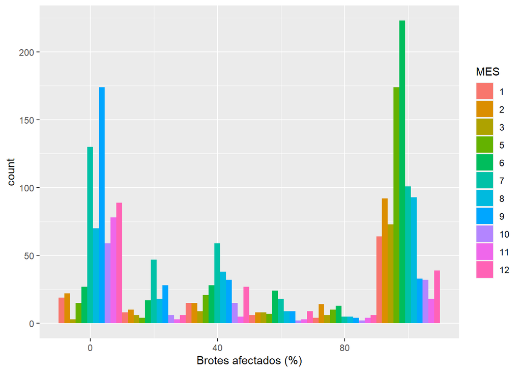

```r
ggplot(db_D_citri_field, aes(`Brotes afectados (%)`, fill = MES)) +
  geom_histogram(binwidth=20, position="dodge")
```

```r
#CULTIVAR
with(db_D_citri_field, tapply(`Brotes afectados (%)`, CULTIVAR, function(x) {
  sprintf("M (SD) = %1.2f (%1.2f)", mean(x), sd(x))
}))
```

```
##                    Limón                Mandarina                  Naranja
## "M (SD) = 56.59 (45.06)" "M (SD) = 49.84 (43.72)" "M (SD) = 56.70 (43.09)"
```

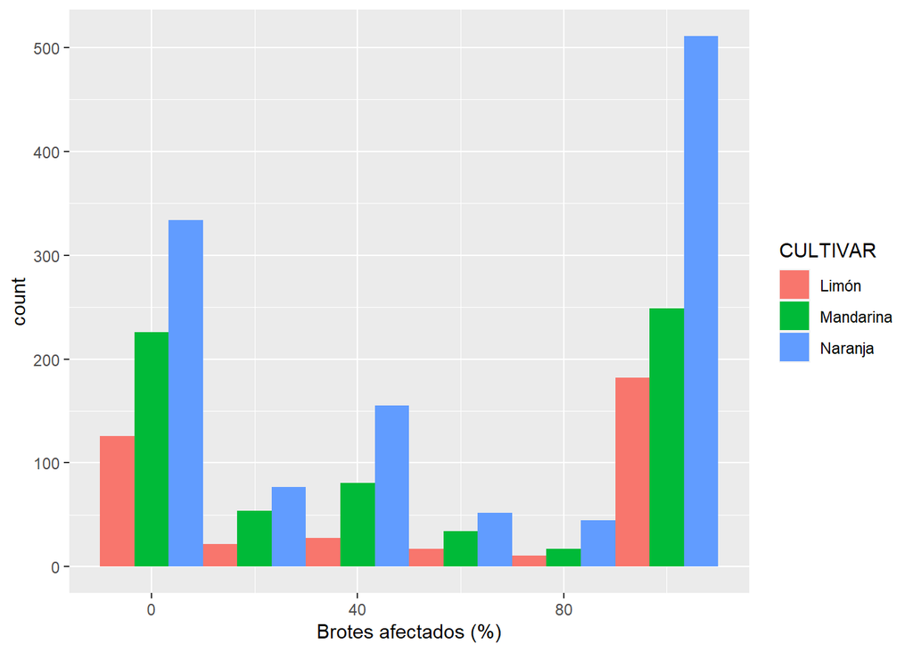

```r
ggplot(db_D_citri_field, aes(`Brotes afectados (%)`, fill = CULTIVAR)) +
  geom_histogram(binwidth=20, position="dodge")
```

```r
#VARIEDAD
with(db_D_citri_field, tapply(`Brotes afectados (%)`, VARIEDAD, function(x) {
  sprintf("M (SD) = %1.2f (%1.2f)", mean(x), sd(x))
}))
```

```
##                   Eureka                Fairchild                 FrostVal
## "M (SD) = 66.42 (44.93)" "M (SD) = 48.96 (44.23)" "M (SD) = 61.26 (42.25)"
##                GarciaVal                   Hamlin               L.Pajarito
## "M (SD) = 53.72 (42.85)" "M (SD) = 56.19 (42.88)" "M (SD) = 49.56 (45.08)"
##                Lannelate               M.Arrayana                  M.Oneco
## "M (SD) = 49.55 (43.66)" "M (SD) = 49.40 (43.85)" "M (SD) = 43.99 (42.69)"
##             OwariSatsuma                  ParsonB               PeraDelRio
## "M (SD) = 57.02 (43.66)" "M (SD) = 49.94 (44.65)" "M (SD) = 64.34 (41.62)"
##                  Perrine               Pinneapple                 Sweety O
## "M (SD) = 57.31 (44.51)" "M (SD) = 59.30 (43.79)" "M (SD) = 61.88 (40.67)"
##             V.Washington
## "M (SD) = 54.75 (44.24)"
```

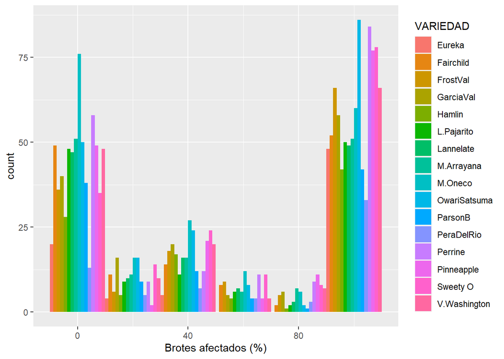

```r
ggplot(db_D_citri_field, aes(`Brotes afectados (%)`, fill = VARIEDAD)) +
  geom_histogram(binwidth=20, position="dodge")
```

```r
#PORTAINJERTO
with(db_D_citri_field, tapply(`Brotes afectados (%)`, PORTAINJERTO, function(x) {
  sprintf("M (SD) = %1.2f (%1.2f)", mean(x), sd(x))
}))
```

```
##                  CPB4475                      SxE
## "M (SD) = 56.15 (43.21)" "M (SD) = 53.51 (44.08)"
```

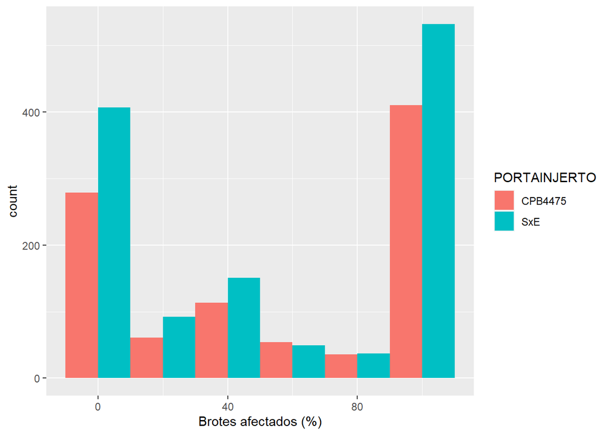

```r
ggplot(db_D_citri_field, aes(`Brotes afectados (%)`, fill = PORTAINJERTO)) +
  geom_histogram(binwidth=20, position="dodge")
```

```r
#PUNTO
with(db_D_citri_field, tapply(`Brotes afectados (%)`, PUNTO, function(x) {
  sprintf("M (SD) = %1.2f (%1.2f)", mean(x), sd(x))
}))
```

```
##                     ESTE                    NORTE                    OESTE
## "M (SD) = 57.63 (43.75)" "M (SD) = 54.82 (43.48)" "M (SD) = 54.56 (43.74)"
##                      SUR
## "M (SD) = 51.32 (43.79)"
```

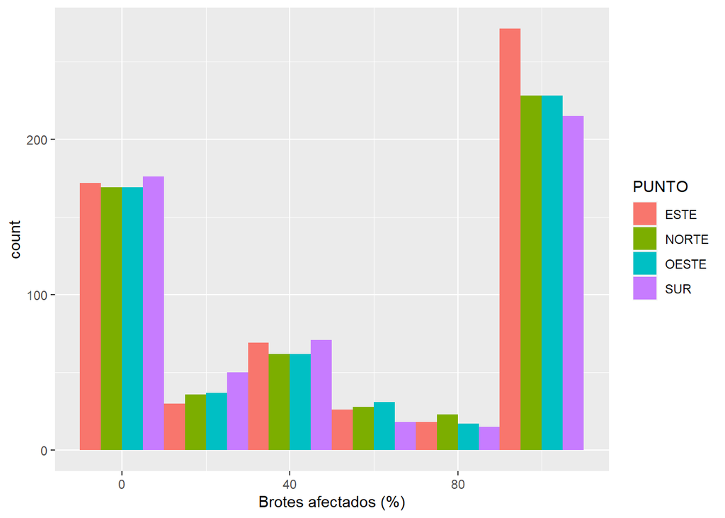

```r
ggplot(db_D_citri_field, aes(`Brotes afectados (%)`, fill = PUNTO)) +
  geom_histogram(binwidth=20, position="dodge")
```

## 5. Ajuste al modelo Poisson

Se intenta ajustar los datos a un modelo con distribución Poisson, pero la distribución de estos datos no se ajustan al modelo. Se procede a realizar un test no paramétrico de Kruskal Wallis

```r
#Model poisson distribution https://stats.idre.ucla.edu/r/dae/poisson-regression/----
summary(m1 <- glm(`Brotes afectados (%)` ~ MES+CULTIVAR+VARIEDAD+PORTAINJERTO+PUNTO, family="poisson", data=db_D_citri_field))
```

```
##
## Call:
## glm(formula = `Brotes afectados (%)` ~ MES + CULTIVAR + VARIEDAD +
##     PORTAINJERTO + PUNTO, family = "poisson", data = db_D_citri_field)
##
## Deviance Residuals:
##     Min       1Q   Median       3Q      Max
## -13.903   -6.747    0.448    2.987   13.140
##
## Coefficients: (2 not defined because of singularities)
##                       Estimate Std. Error z value Pr(>|z|)
## (Intercept)           4.418622   0.018979 232.822  < 2e-16 ***
## MES2                  0.047377   0.014619   3.241 0.001192 **
## MES3                  0.177744   0.015671  11.342  < 2e-16 ***
## MES5                  0.199589   0.013417  14.876  < 2e-16 ***
## MES6                  0.143625   0.012879  11.152  < 2e-16 ***
## MES7                 -0.489162   0.013905 -35.179  < 2e-16 ***
## MES8                 -0.271828   0.014488 -18.763  < 2e-16 ***
## MES9                 -1.145489   0.017095 -67.005  < 2e-16 ***
## MES10                -0.622491   0.019076 -32.632  < 2e-16 ***
## MES11                -1.082711   0.022765 -47.561  < 2e-16 ***
## MES12                -0.643519   0.016928 -38.016  < 2e-16 ***
## CULTIVARMandarina    -0.078846   0.017166  -4.593 4.36e-06 ***
## CULTIVARNaranja      -0.085364   0.017857  -4.781 1.75e-06 ***
## VARIEDADFairchild    -0.095168   0.015697  -6.063 1.34e-09 ***
## VARIEDADFrostVal      0.070757   0.015378   4.601 4.20e-06 ***
## VARIEDADGarciaVal    -0.054276   0.015739  -3.448 0.000564 ***
## VARIEDADHamlin        0.010823   0.017409   0.622 0.534119
## VARIEDADL.Pajarito   -0.156326   0.019037  -8.212  < 2e-16 ***
## VARIEDADLannelate    -0.074743   0.016522  -4.524 6.08e-06 ***
## VARIEDADM.Arrayana   -0.084172   0.015437  -5.453 4.97e-08 ***
## VARIEDADM.Oneco      -0.227965   0.014562 -15.655  < 2e-16 ***
## VARIEDADOwariSatsuma        NA         NA      NA       NA
## VARIEDADParsonB      -0.017281   0.017615  -0.981 0.326569
## VARIEDADPeraDelRio    0.043501   0.019155   2.271 0.023147 *
## VARIEDADPerrine      -0.095068   0.017204  -5.526 3.28e-08 ***
## VARIEDADPinneapple    0.088779   0.014952   5.938 2.89e-09 ***
## VARIEDADSweety O      0.133425   0.014670   9.095  < 2e-16 ***
## VARIEDADV.Washington        NA         NA      NA       NA
## PORTAINJERTOSxE      -0.060982   0.005945 -10.258  < 2e-16 ***
## PUNTONORTE           -0.054689   0.007956  -6.874 6.25e-12 ***
## PUNTOOESTE           -0.039171   0.007981  -4.908 9.20e-07 ***
## PUNTOSUR             -0.115331   0.008100 -14.238  < 2e-16 ***
## ---
## Signif. codes:  0 '***' 0.001 '**' 0.01 '*' 0.05 '.' 0.1 ' ' 1
##
## (Dispersion parameter for poisson family taken to be 1)
##
##     Null deviance: 108591  on 2220  degrees of freedom
## Residual deviance:  85329  on 2191  degrees of freedom
## AIC: 94828
##
## Number of Fisher Scoring iterations: 6
```

```r
# cov.m1 <- vcovHC(m1, type="HC0")
# std.err <- sqrt(diag(cov.m1))
# r.est <- cbind(Estimate= coef(m1), "Robust SE" = std.err,
#                "Pr(>|z|)" = 2 * pnorm(abs(coef(m1)/std.err), lower.tail=FALSE),
#                LL = coef(m1) - 1.96 * std.err,
#                UL = coef(m1) + 1.96 * std.err)
#
# r.est
```

## 6. Prueba no paramétrica

### Kruskal Wallis para el factor mes

De acuerdo con la distribución de los datos se decide dividir las observaciones en tres grupos con distribuciones similares así (el mes 4 no tiene datos):

#### group_1<- c(1:3)

compuesto por los meses 1,2 y 3 #### group_2<- c(5:6,8) compuesto por los meses 5,6 y 8 #### group_3<- c(7,9,10:12) compuesto por los meses7, 9, 10, 11 y 12

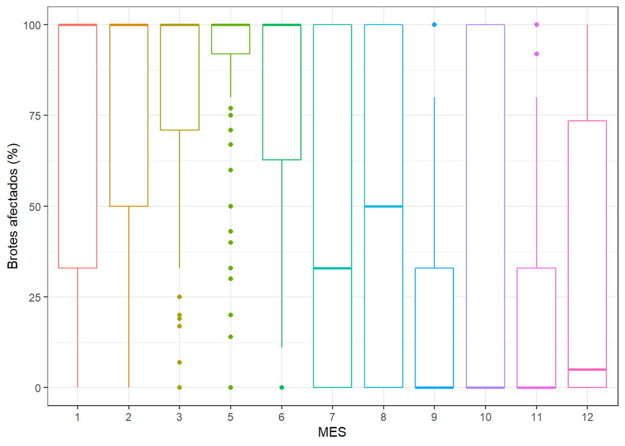

```r
#Non-parametric approach----
#Boxplot MES
ggplot(data = db_D_citri_field, mapping = aes(x = MES, y = `Brotes afectados (%)`, colour = MES)) +
  geom_boxplot() +
  theme_bw() +
  theme(legend.position = "none")
```

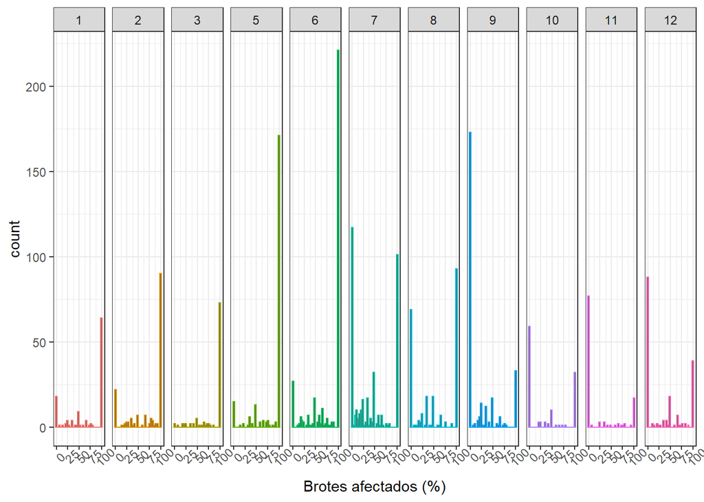

```r
#Distribution MES
 ggplot(data = db_D_citri_field, mapping = aes(x = `Brotes afectados (%)`, colour = MES)) +
  geom_histogram() +
  theme_bw() +
  facet_grid(. ~ MES) +
  theme(legend.position = "none")+
  theme(axis.text.x = element_text(angle = 45))
```

```r
##Note: According to distribution plots moths months with same distribition could be:
##group_1<- c(1:3)
##group_2<- c(5:6,8)
##group_3<- c(7,9,10:12)
#KW test group_1
group_1_month<- kruskal(db_D_citri_field[db_D_citri_field$MES %in% c(1:3),]$`Brotes afectados (%)`, db_D_citri_field[db_D_citri_field$MES %in% c(1:3),]$MES,group=TRUE, p.adj = "bonferroni")
group_1_month
```

```
## $statistics
##      Chisq Df    p.chisq
##   8.856605  2 0.01193473
##
## $parameters
##             test  p.ajusted
##   Kruskal-Wallis bonferroni
##                                                     name.t ntr alpha
##   db_D_citri_field[db_D_citri_field$MES %in% c(1:3), ]$MES   3  0.05
##
## $means
##   db_D_citri_field.db_D_citri_field.MES..in..c.1.3......Brotes.afectados.....
## 1                                                                    68.47414
## 2                                                                    72.83851
## 3                                                                    83.66667
##       rank      std   r Min Max Q25 Q50 Q75
## 1 178.4052 39.35158 116   0 100  33 100 100
## 2 185.4317 37.50715 161   0 100  50 100 100
## 3 215.2714 28.11674 105   0 100  71 100 100
##
## $comparison
## NULL
##
## $groups
##   db_D_citri_field[db_D_citri_field$MES %in% c(1:3), ]$`Brotes afectados (%)`
## 3                                                                    215.2714
## 2                                                                    185.4317
## 1                                                                    178.4052
##   groups
## 3      a
## 2      b
## 1      b
##
## attr(,"class")
## [1] "group"
```

```r
#KW test group_2
group_2_month<- kruskal(db_D_citri_field[db_D_citri_field$MES %in% c(5:6,8),]$`Brotes afectados (%)`, db_D_citri_field[db_D_citri_field$MES %in% c(5:6,8),]$MES,group=TRUE, p.adj = "bonferroni")
group_2_month
```

```
## $statistics
##      Chisq Df p.chisq
##   87.70684  2       0
##
## $parameters
##             test  p.ajusted
##   Kruskal-Wallis bonferroni
##                                                        name.t ntr alpha
##   db_D_citri_field[db_D_citri_field$MES %in% c(5:6, 8), ]$MES   3  0.05
##
## $means
##   db_D_citri_field.db_D_citri_field.MES..in..c.5.6..8......Brotes.afectados.....
## 5                                                                       84.89610
## 6                                                                       79.52711
## 8                                                                       52.63519
##       rank      std   r Min Max   Q25 Q50 Q75
## 5 458.4892 29.75593 231   0 100 92.00 100 100
## 6 428.6054 33.37875 332   0 100 62.75 100 100
## 8 296.1288 43.19592 233   0 100  0.00  50 100
##
## $comparison
## NULL
##
## $groups
##   db_D_citri_field[db_D_citri_field$MES %in% c(5:6, 8), ]$`Brotes afectados (%)`
## 5                                                                       458.4892
## 6                                                                       428.6054
## 8                                                                       296.1288
##   groups
## 5      a
## 6      a
## 8      b
##
## attr(,"class")
## [1] "group"
```

```r
#KW test group_3
group_3_month<- kruskal(db_D_citri_field[db_D_citri_field$MES %in% c(7,9,10:12),]$`Brotes afectados (%)`, db_D_citri_field[db_D_citri_field$MES %in% c(7,9,10:12),]$MES,group=TRUE, p.adj = "bonferroni")
group_3_month
```

```
## $statistics
##      Chisq Df      p.chisq
##   62.97134  4 6.881162e-13
##
## $parameters
##             test  p.ajusted
##   Kruskal-Wallis bonferroni
##                                                             name.t ntr alpha
##   db_D_citri_field[db_D_citri_field$MES %in% c(7, 9, 10:12), ]$MES   5  0.05
##
## $means
##    db_D_citri_field.db_D_citri_field.MES..in..c.7..9..10.12......Brotes.afectados.....
## 10                                                                            36.97414
## 11                                                                            23.09910
## 12                                                                            36.02841
## 7                                                                             42.36389
## 9                                                                             22.06429
##        rank      std   r Min Max Q25 Q50   Q75
## 10 535.6897 43.25244 116   0 100   0   0 100.0
## 11 429.7027 38.67815 111   0 100   0   0  33.0
## 12 532.9034 41.39198 176   0 100   0   5  73.5
## 7  601.4875 40.98683 360   0 100   0  33 100.0
## 9  443.8661 34.33625 280   0 100   0   0  33.0
##
## $comparison
## NULL
##
## $groups
##    db_D_citri_field[db_D_citri_field$MES %in% c(7, 9, 10:12), ]$`Brotes afectados (%)`
## 7                                                                             601.4875
## 10                                                                            535.6897
## 12                                                                            532.9034
## 9                                                                             443.8661
## 11                                                                            429.7027
##    groups
## 7       a
## 10      a
## 12      a
## 9       b
## 11      b
##
## attr(,"class")
## [1] "group"
```

### Kruskal Wallis para el factor Cultivar

De acuerdo con la distribución de los datos se decide dividir las observaciones en 1 grupo con distribuciones similares así :

#### group_1<- c(“Limón”, “Mandarina”, “Naranja”)

compuesto por los tres cultivares

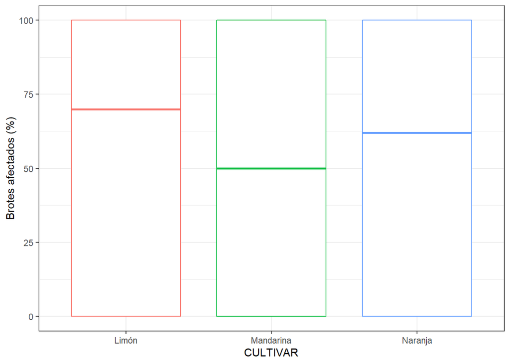

```r
#Boxplot CULTIVAR
ggplot(data = db_D_citri_field, mapping = aes(x = CULTIVAR, y = `Brotes afectados (%)`, colour = CULTIVAR)) +
  geom_boxplot() +
  theme_bw() +
  theme(legend.position = "none")
```

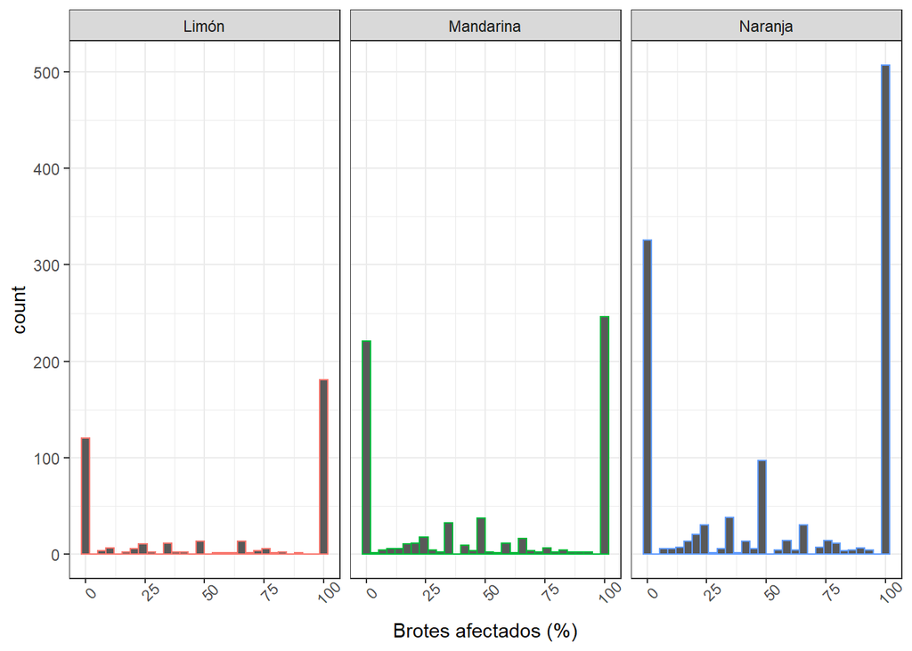

```r
#Distribution CULTIVAR
 ggplot(data = db_D_citri_field, mapping = aes(x = `Brotes afectados (%)`, colour = CULTIVAR)) +
  geom_histogram() +
  theme_bw() +
  facet_grid(. ~ CULTIVAR) +
  theme(legend.position = "none")+
  theme(axis.text.x = element_text(angle = 45))
```

```r
##Note: According to distribution plots CULTIVAR with same distribition could be: Limón, Mandarina, and Naranja
#KW test group_1
group_CULTIVAR<- kruskal(db_D_citri_field$`Brotes afectados (%)`, db_D_citri_field$CULTIVAR,group=TRUE, p.adj = "bonferroni")
group_CULTIVAR
```

```
## $statistics
##      Chisq Df     p.chisq
##   10.64115  2 0.004889943
##
## $parameters
##             test  p.ajusted                    name.t ntr alpha
##   Kruskal-Wallis bonferroni db_D_citri_field$CULTIVAR   3  0.05
##
## $means
##           db_D_citri_field..Brotes.afectados.....     rank      std    r Min
## Limón                                    56.59326 1140.263 45.06022  386   0
## Mandarina                                49.84115 1046.387 43.71884  661   0
## Naranja                                  56.70017 1137.758 43.09403 1174   0
##           Max Q25 Q50 Q75
## Limón     100   0  70 100
## Mandarina 100   0  50 100
## Naranja   100   0  62 100
##
## $comparison
## NULL
##
## $groups
##           db_D_citri_field$`Brotes afectados (%)` groups
## Limón                                    1140.263      a
## Naranja                                  1137.758      a
## Mandarina                                1046.387      b
##
## attr(,"class")
## [1] "group"
```

### Kruskal Wallis para el factor Variedad

De acuerdo con la distribución de los datos se decide dividir las observaciones en 1 grupo con distribuciones similares así:

#### group_1<- Todas las observaciones menos la mandarina oneco

compuesto todas las variedades menos la mandarina oneco. Sin embargo, se decide adicionar la variedad oneco en el estadístico dado que de quedarse sola la variedad Oneco no se podría realizar el comparativo

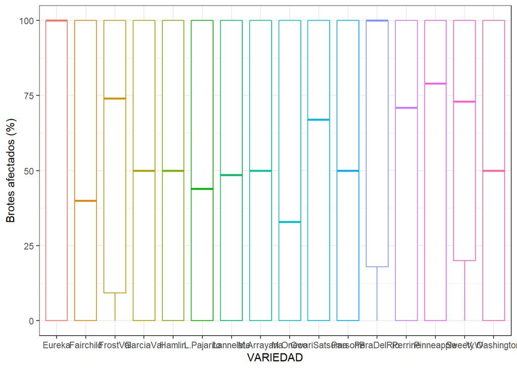

```r
#Boxplot VARIEDAD
ggplot(data = db_D_citri_field, mapping = aes(x = VARIEDAD, y = `Brotes afectados (%)`, colour = VARIEDAD)) +
  geom_boxplot() +
  theme_bw() +
  theme(legend.position = "none")
```

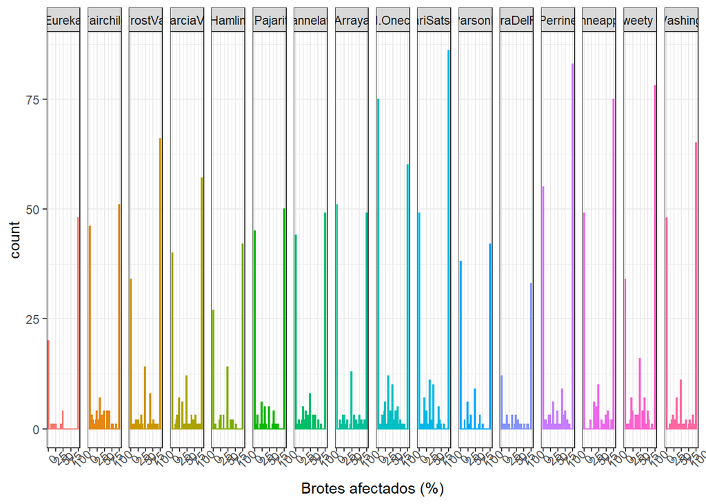

```r
#Distribution VARIEDAD
 ggplot(data = db_D_citri_field, mapping = aes(x = `Brotes afectados (%)`, colour = VARIEDAD)) +
  geom_histogram() +
  theme_bw() +
  facet_grid(. ~ VARIEDAD) +
  theme(legend.position = "none")+
  theme(axis.text.x = element_text(angle = 45))
```

```r
##Note: According to distribution plots VARIEDAD with same distribition could be:
#group 1: all except oneco
#group 2: oneco
#However kw test coulb be done with all varieties
#KW test group_1
group_VARIEDAD<- kruskal(db_D_citri_field$`Brotes afectados (%)`, db_D_citri_field$VARIEDAD,group=TRUE, p.adj = "bonferroni")
group_VARIEDAD
```

```
## $statistics
##      Chisq Df      p.chisq
##   40.26812 15 0.0004130917
##
## $parameters
##             test  p.ajusted                    name.t ntr alpha
##   Kruskal-Wallis bonferroni db_D_citri_field$VARIEDAD  16  0.05
##
## $means
##              db_D_citri_field..Brotes.afectados.....     rank      std   r Min
## Eureka                                      66.41558 1284.584 44.92812  77   0
## Fairchild                                   48.96324 1039.221 44.22944 136   0
## FrostVal                                    61.26429 1198.950 42.25422 140   0
## GarciaVal                                   53.72414 1100.066 42.85238 145   0
## Hamlin                                      56.18557 1135.582 42.88413  97   0
## L.Pajarito                                  49.55556 1046.488 45.08012 126   0
## Lannelate                                   49.54545 1044.087 43.65852 132   0
## M.Arrayana                                  49.40141 1026.373 43.84920 142   0
## M.Oneco                                     43.98985  964.203 42.69111 197   0
## OwariSatsuma                                57.01613 1153.952 43.65794 186   0
## ParsonB                                     49.94340 1049.193 44.64523 106   0
## PeraDelRio                                  64.33846 1249.738 41.62079  65   0
## Perrine                                     57.30601 1144.104 44.50675 183   0
## Pinneapple                                  59.30488 1161.463 43.78732 164   0
## Sweety O                                    61.88235 1210.921 40.67403 170   0
## V.Washington                                54.75484 1107.161 44.23804 155   0
##              Max   Q25   Q50 Q75
## Eureka       100  0.00 100.0 100
## Fairchild    100  0.00  40.0 100
## FrostVal     100  9.25  74.0 100
## GarciaVal    100  0.00  50.0 100
## Hamlin       100  0.00  50.0 100
## L.Pajarito   100  0.00  44.0 100
## Lannelate    100  0.00  48.5 100
## M.Arrayana   100  0.00  50.0 100
## M.Oneco      100  0.00  33.0 100
## OwariSatsuma 100  0.00  67.0 100
## ParsonB      100  0.00  50.0 100
## PeraDelRio   100 18.00 100.0 100
## Perrine      100  0.00  71.0 100
```

[output cut: 13 more lines]

```
## Pinneapple                                  1161.463     ab
## OwariSatsuma                                1153.952     ab
## Perrine                                     1144.104     ab
## Hamlin                                      1135.582     ab
## V.Washington                                1107.161     ab
## GarciaVal                                   1100.066     ab
## ParsonB                                     1049.193     ab
## L.Pajarito                                  1046.488     ab
## Lannelate                                   1044.087     ab
## Fairchild                                   1039.221     ab
## M.Arrayana                                  1026.373     ab
## M.Oneco                                      964.203      b
##
## attr(,"class")
## [1] "group"
```

### Kruskal Wallis para el factor Portainjerto

De acuerdo con la distribución de los datos se decide dividir las observaciones en 1 grupo con distribuciones similares así:

#### group_1<- CPB4475 y SxE

Se recomienda para futuros análisis usar la prueba de Wilcoxon en lugar de la Kruskal dado que solo se están comparando don niveles de un factor

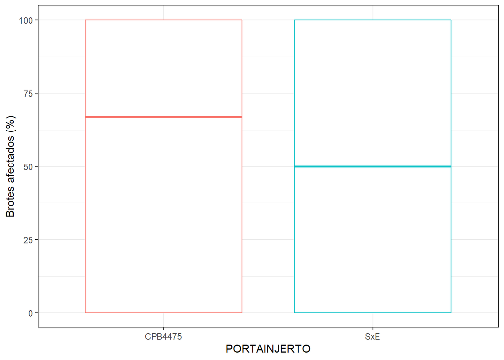

```r
#Boxplot PORTAINJERTO
ggplot(data = db_D_citri_field, mapping = aes(x = PORTAINJERTO, y = `Brotes afectados (%)`, colour = PORTAINJERTO)) +
  geom_boxplot() +
  theme_bw() +
  theme(legend.position = "none")
```

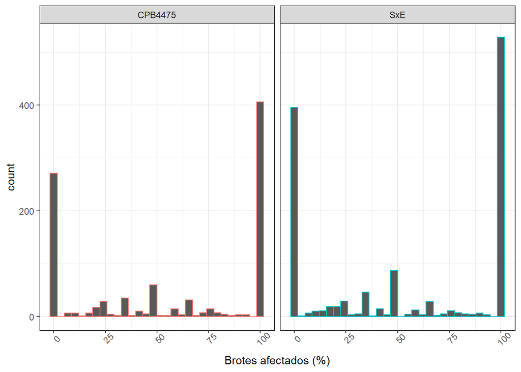

```r
#Distribution PORTAINJERTO
 ggplot(data = db_D_citri_field, mapping = aes(x = `Brotes afectados (%)`, colour = PORTAINJERTO)) +
  geom_histogram() +
  theme_bw() +
  facet_grid(. ~ PORTAINJERTO) +
  theme(legend.position = "none")+
  theme(axis.text.x = element_text(angle = 45))
```

```r
##Note: According to distribution plots PORTAINJERTO with same distribition could be: CPB AND SXE
#KW test group_1
group_PORTAINJERTO<- kruskal(db_D_citri_field$`Brotes afectados (%)`, db_D_citri_field$PORTAINJERTO,group=TRUE, p.adj = "bonferroni")
group_PORTAINJERTO
```

```
## $statistics
##      Chisq Df   p.chisq
##   1.615741  1 0.2036867
##
## $parameters
##             test  p.ajusted                        name.t ntr alpha
##   Kruskal-Wallis bonferroni db_D_citri_field$PORTAINJERTO   2  0.05
##
## $means
##         db_D_citri_field..Brotes.afectados.....     rank      std    r Min Max
## CPB4475                                56.14900 1129.909 43.21039  953   0 100
## SxE                                    53.50631 1096.789 44.08082 1268   0 100
##         Q25 Q50 Q75
## CPB4475   0  67 100
## SxE       0  50 100
##
## $comparison
## NULL
##
## $groups
##         db_D_citri_field$`Brotes afectados (%)` groups
## CPB4475                                1129.909      a
## SxE                                    1096.789      a
##
## attr(,"class")
## [1] "group"
```

### Kruskal Wallis para el factor Punto cardinal

De acuerdo con la distribución de los datos se decide dividir las observaciones en 1 grupo con distribuciones similares así:

#### group_1<- todos los puntos cardinales

El grupo está conformado por todos los puntos cardinales

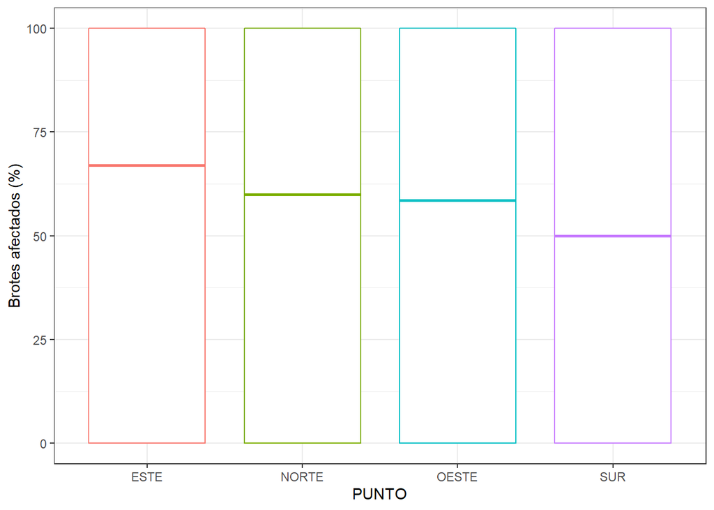

```r
#Boxplot PUNTO
ggplot(data = db_D_citri_field, mapping = aes(x = PUNTO, y = `Brotes afectados (%)`, colour = PUNTO)) +
  geom_boxplot() +
  theme_bw() +
  theme(legend.position = "none")
```

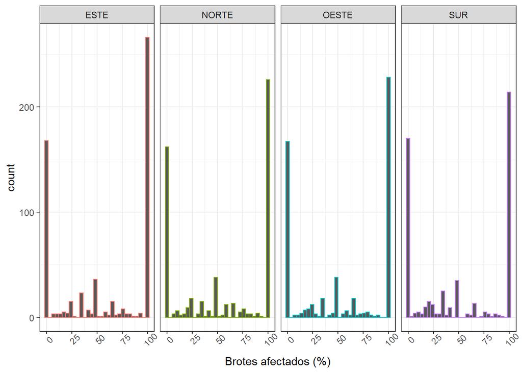

```r
#Distribution PUNTO
 ggplot(data = db_D_citri_field, mapping = aes(x = `Brotes afectados (%)`, colour = PUNTO)) +
  geom_histogram() +
  theme_bw() +
  facet_grid(. ~ PUNTO) +
  theme(legend.position = "none")+
  theme(axis.text.x = element_text(angle = 45))
```

```r
##Note: According to distribution plots PUNTO with same distribition could be: CPB AND SXE
#KW test group_1
group_PUNTO<- kruskal(db_D_citri_field$`Brotes afectados (%)`, db_D_citri_field$PUNTO,group=TRUE, p.adj = "bonferroni")
group_PUNTO
```

```
## $statistics
##      Chisq Df   p.chisq
##   4.858879  3 0.1824272
##
## $parameters
##             test  p.ajusted                 name.t ntr alpha
##   Kruskal-Wallis bonferroni db_D_citri_field$PUNTO   4  0.05
##
## $means
##       db_D_citri_field..Brotes.afectados.....     rank      std   r Min Max Q25
## ESTE                                 57.62628 1150.222 43.74946 586   0 100   0
## NORTE                                54.82051 1111.648 43.48220 546   0 100   0
## OESTE                                54.56434 1108.582 43.74086 544   0 100   0
## SUR                                  51.32477 1070.592 43.78624 545   0 100   0
##        Q50 Q75
## ESTE  67.0 100
## NORTE 60.0 100
## OESTE 58.5 100
## SUR   50.0 100
##
## $comparison
## NULL
##
## $groups
##       db_D_citri_field$`Brotes afectados (%)` groups
## ESTE                                 1150.222      a
## NORTE                                1111.648      a
## OESTE                                1108.582      a
## SUR                                  1070.592      a
##
## attr(,"class")
## [1] "group"
```

#### Se adjunta los gráficos en Power Point